# COMPSCIX 415.2 Homework 5/Midterm

#### Do the results make sense? Why?

```r
diamonds %>% mutate(price_per_carat=price/carat) %>% arrange(price_per_carat)
```

```
## # A tibble: 53,940 x 11
##    carat cut       color clarity depth table price     x     y     z
##    <dbl> <ord>     <ord> <ord>   <dbl> <dbl> <int> <dbl> <dbl> <dbl>
##  1 0.430 Premium   H     I1       62.0  59.0   452  4.78  4.83  2.98
##  2 0.320 Premium   E     I1       60.9  58.0   345  4.38  4.42  2.68
##  3 0.310 Good      J     SI2      63.3  58.0   335  4.34  4.35  2.75
##  4 0.330 Ideal     J     SI2      62.4  54.0   366  4.43  4.45  2.77
##  5 0.310 Ideal     J     SI2      62.2  54.0   344  4.35  4.37  2.71
##  6 0.320 Good      D     I1       64.0  54.0   361  4.33  4.36  2.78
##  7 0.300 Good      J     SI1      64.0  55.0   339  4.25  4.28  2.73
##  8 0.310 Very Good J     SI1      59.4  62.0   353  4.39  4.43  2.62
##  9 0.310 Very Good J     SI1      58.1  62.0   353  4.44  4.47  2.59
## 10 0.360 Premium   J     SI1      61.6  60.0   410  4.54  4.58  2.81
## # ... with 53,930 more rows, and 1 more variable: price_per_carat <dbl>
```

```r
diamonds %>% mutate(price_per_carat=price/carat) %>% arrange(desc(price_per_carat))
```

```
## # A tibble: 53,940 x 11
##    carat cut       color clarity depth table price     x     y     z
##    <dbl> <ord>     <ord> <ord>   <dbl> <dbl> <int> <dbl> <dbl> <dbl>
##  1  1.04 Very Good D     IF       61.3  56.0 18542  6.53  6.55  4.01
##  2  1.07 Premium   D     IF       60.9  58.0 18279  6.67  6.57  4.03
##  3  1.03 Ideal     D     IF       62.0  56.0 17590  6.55  6.44  4.03
##  4  1.07 Very Good D     IF       60.9  58.0 18114  6.57  6.67  4.03
##  5  1.02 Very Good D     IF       61.7  59.0 17100  6.42  6.52  3.99
##  6  1.07 Very Good D     IF       59.0  59.0 17909  6.63  6.72  3.94
##  7  1.09 Very Good D     IF       61.7  58.0 18231  6.55  6.65  4.07
##  8  1.00 Ideal     D     IF       60.7  57.0 16469  6.44  6.48  3.92
##  9  1.01 Premium   D     IF       61.6  56.0 16234  6.46  6.43  3.97
## 10  1.00 Very Good D     IF       63.3  59.0 16073  6.37  6.33  4.02
## # ... with 53,930 more rows, and 1 more variable: price_per_carat <dbl>
```

Eyeballing two groupings, we can see that the most expensive per carat diamonds, compared to the least expensive, seem to have the best color and clarity, although not necessarily the best cut. We can graph frequencies of price per carat grouped by cut, which shows that the best cut diamonds actually are not the most expensive per carat:

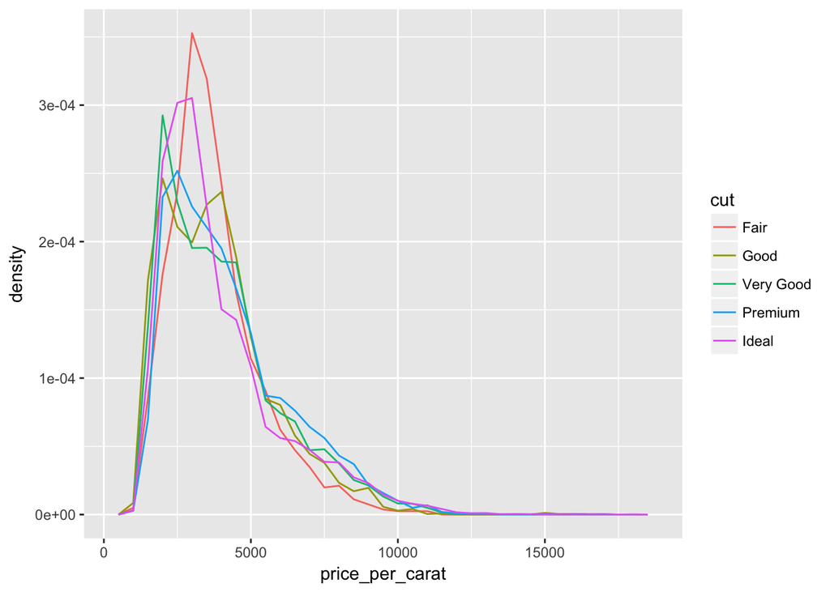

```r
diamonds %>% mutate(price_per_carat=price/carat) %>% ggplot(mapping=aes(x=price_per_carat, y = ..density..)) + geom_freqpoly(mapping = aes(color = cut), binwidth = 500)
```

We can group diamonds by color, clarity, and cut and compare average price per carat:

```r
diamonds %>% mutate(price_per_carat=price/carat) %>% group_by(color, clarity, cut) %>% summarize(count=n(), average_price_per_carat=mean(price_per_carat)) %>% arrange(desc(average_price_per_carat))
```

```
## # A tibble: 276 x 5
## # Groups:   color, clarity [56]
##    color clarity cut       count average_price_per_carat
##    <ord> <ord>   <ord>     <int>                   <dbl>
##  1 D     IF      Very Good    23                   11347
##  2 D     IF      Good          9                   10877
##  3 D     IF      Premium      10                   10099
##  4 D     IF      Ideal        28                    9034
##  5 E     IF      Premium      27                    5817
##  6 E     IF      Very Good    43                    5706
##  7 D     VVS1    Fair          3                    5690
##  8 F     IF      Very Good    67                    5544
##  9 E     VVS1    Fair          3                    5447
## 10 H     IF      Good          4                    5394
## # ... with 266 more rows
```

Graphing a heatmap shows somewhat of a trend towards higher price per carat with better clarity and cut, but it is not a very strong trend.

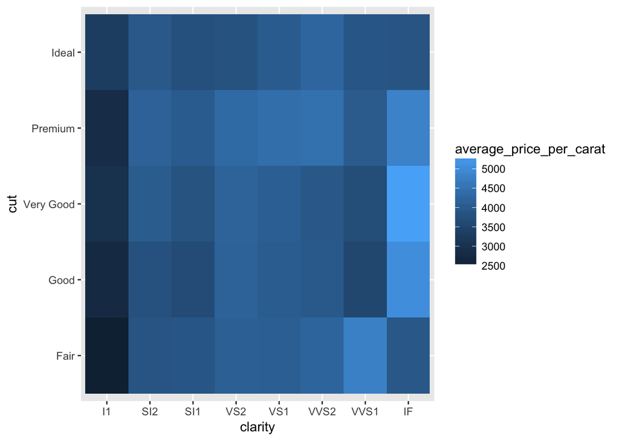

```r
diamonds %>% mutate(price_per_carat=price/carat) %>% group_by(clarity, cut) %>% summarize(count=n(), average_price_per_carat=mean(price_per_carat)) %>% arrange(desc(average_price_per_carat)) %>% ggplot(mapping = aes(x = clarity, y = cut)) + geom_tile(mapping = aes(fill = average_price_per_carat))
```

Graphing the same heat map but for clarity and color (which, according to our eyeball estimate, seem to be the strongest predictors of price per carat) reveals only that the best color and clarity diamonds (represended by right- and bottom-most tile) are more expensive per carat than all others, and that the least clear diamonds cost less per carat regardless of the color. Other trends are not very clear. Overall, there are (at least) three different variables determining the price of a diamond per carat, and the trends determining the price are not very clear.

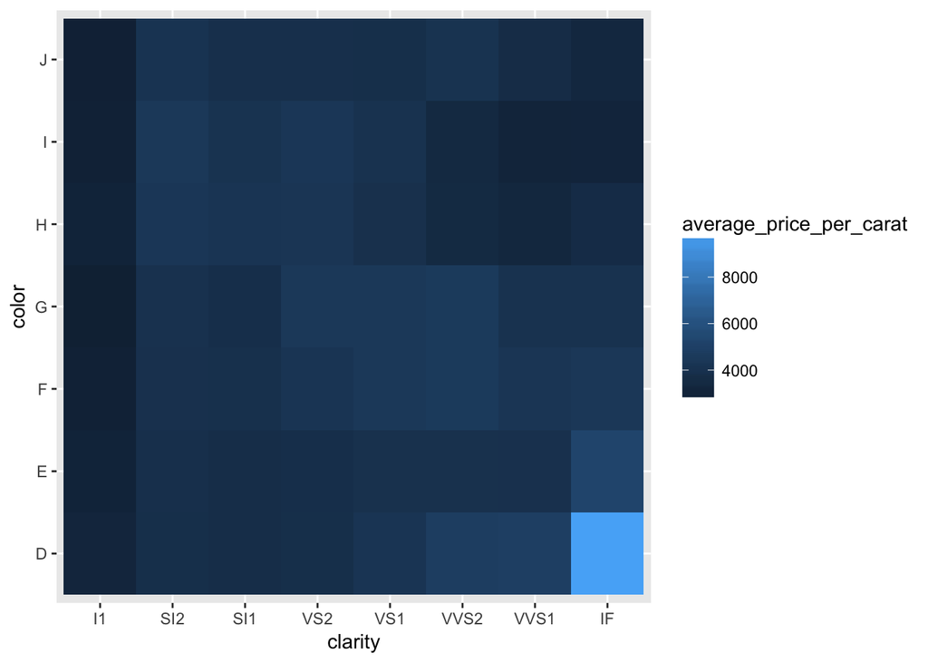

```r
diamonds %>% mutate(price_per_carat=price/carat) %>% group_by(clarity, color) %>% summarize(count=n(), average_price_per_carat=mean(price_per_carat)) %>% arrange(desc(average_price_per_carat)) %>% ggplot(mapping = aes(x = clarity, y = color)) + geom_tile(mapping = aes(fill = average_price_per_carat))
```

#### Do we need to be wary of any of these numbers? Why?

Graphing a distribution of prices per carat grouped by cut, we see that Ideal cut diamonds do not have the highest price per carat.

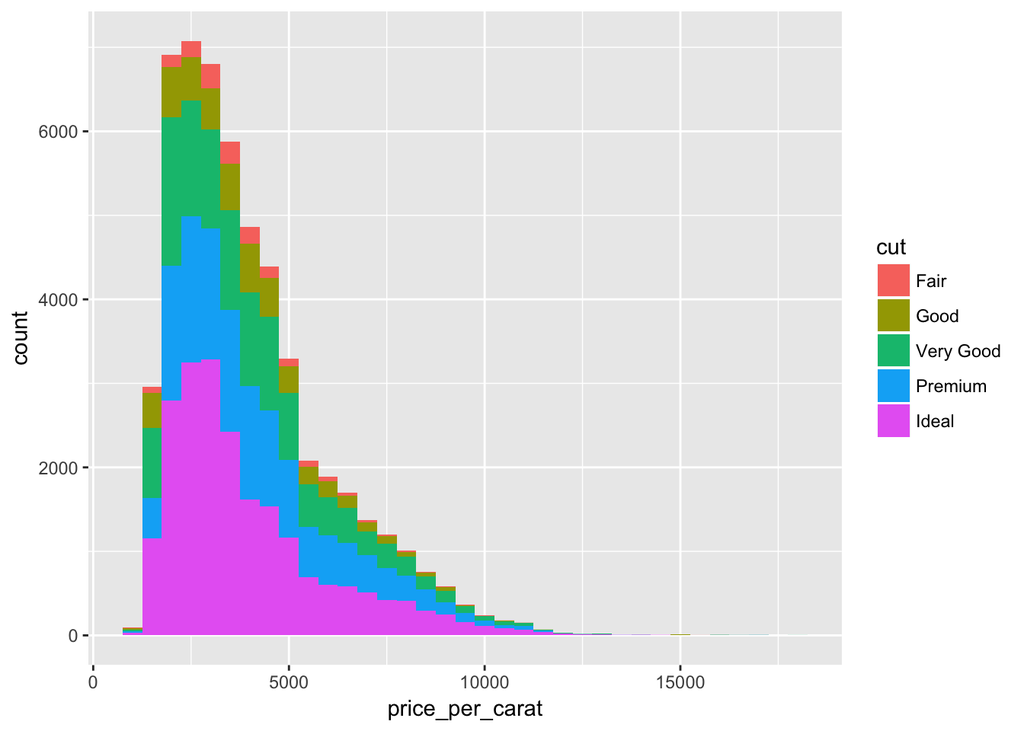

```r
diamonds %>% mutate(price_per_carat=price/carat) %>% ggplot(mapping=aes(x=price_per_carat, fill=cut)) + geom_histogram(binwidth=500)
```

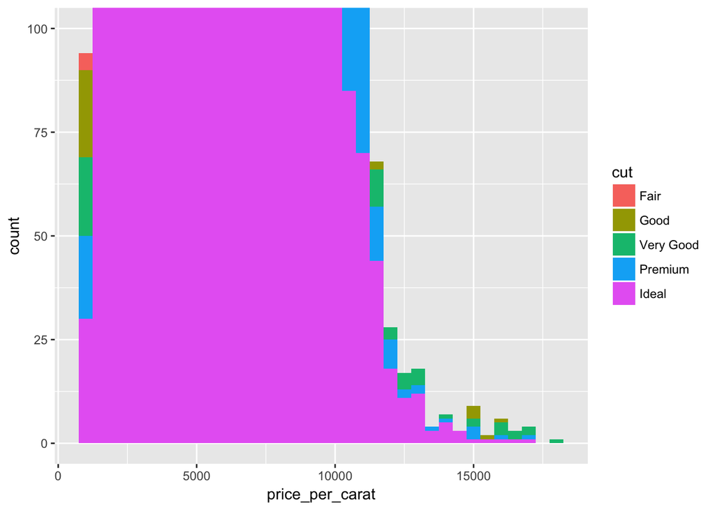

```r
diamonds %>% mutate(price_per_carat=price/carat) %>% ggplot(mapping=aes(x=price_per_carat, fill=cut)) + geom_histogram(binwidth=500) + coord_cartesian(ylim = c(0, 100))
```

This may cause is to be wary of some of the observations with high price per carat.

## EDA (6 points)

Take a look at the txhousing data set that is included with the ggplot2 package and answer these questions:

### 1. During what time period is this data from?

```r
tx_mod <- txhousing %>% mutate(padded_month=str_pad(txhousing$month, 2, pad='0')) %>% unite(yearmonth, year, padded_month, sep='-')
min(tx_mod$yearmonth)
```

```
## [1] "2000-01"
```

```r
max(tx_mod$yearmonth)
```

```
## [1] "2015-07"
```

The data is from January 2000 to July 2015.

### 2. How many cities are represented?

```r
count(distinct(txhousing, city))
```

```
## # A tibble: 1 x 1
##       n
##   <int>
## 1    46
```

### 3. Which city, month and year had the highest number of sales?

```r
txhousing %>% group_by(city, month, year) %>% summarize(total_sales=sum(sales)) %>% arrange(desc(total_sales))
```

```
## # A tibble: 8,602 x 4
## # Groups:   city, month [552]
##    city    month  year total_sales
##    <chr>   <int> <int>       <dbl>
##  1 Houston     7  2015        8945
##  2 Houston     6  2006        8628
##  3 Houston     7  2013        8468
##  4 Houston     6  2015        8449
##  5 Houston     5  2013        8439
##  6 Houston     6  2014        8391
##  7 Houston     7  2014        8391
##  8 Houston     8  2014        8167
##  9 Houston     8  2013        8155
## 10 Houston     5  2006        8040
## # ... with 8,592 more rows
```

Houston, July 2015: 8945 sales

### 4. What kind of relationship do you think exists between the number of listings and the number of sales? Check your assumption and show your work.

direct, more or less:

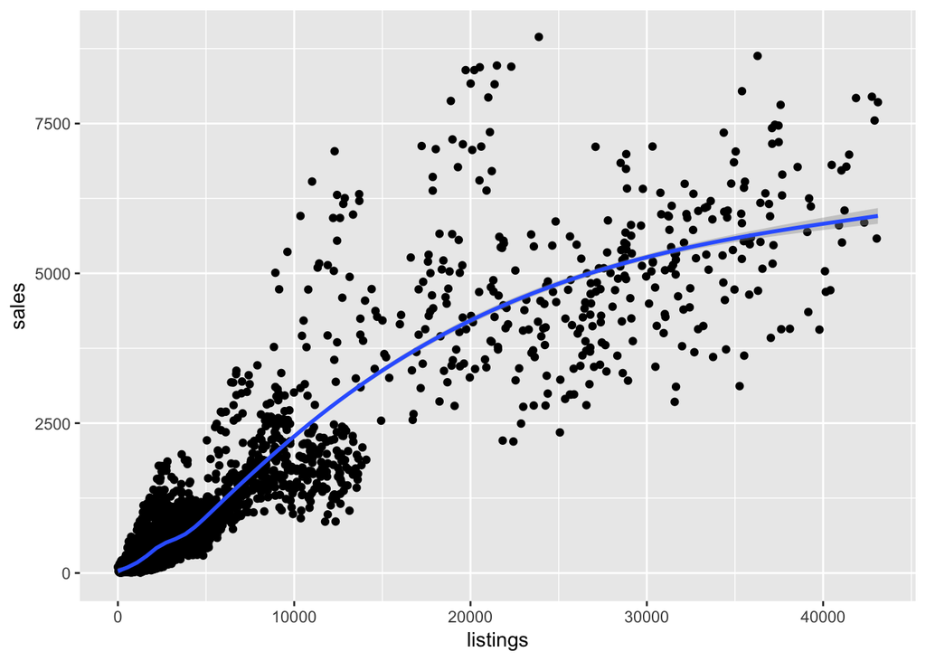

```r
txhousing %>% ggplot(mapping=aes(x=listings, y=sales)) + geom_point(na.rm = TRUE) + geom_smooth(na.rm = TRUE)
```

### 5. What proportion of sales is missing for each city?

```r
txhousing %>% mutate(missing_sale=is.na(sales)) %>% group_by(city) %>% summarize(missing_sales_proportion=mean(missing_sale)) %>% print(n = Inf)
```

```
## # A tibble: 46 x 2
##    city                  missing_sales_proportion
##    <chr>                                    <dbl>
##  1 Abilene                                0
##  2 Amarillo                               0
##  3 Arlington                              0
##  4 Austin                                 0
##  5 Bay Area                               0
##  6 Beaumont                               0
##  7 Brazoria County                        0.0749
##  8 Brownsville                            0.0107
##  9 Bryan-College Station                  0
## 10 Collin County                          0
## 11 Corpus Christi                         0.00535
## 12 Dallas                                 0
```

[output cut: 34 more lines]

### 6. Looking at only the cities and months with greater than 500 sales:

```r
tx_subset <- txhousing %>% filter(sales > 500)
```

#### Are the distributions of the median sales price (column name median), when grouped by city, different? The same? Show your work.

Distributions by city are different:

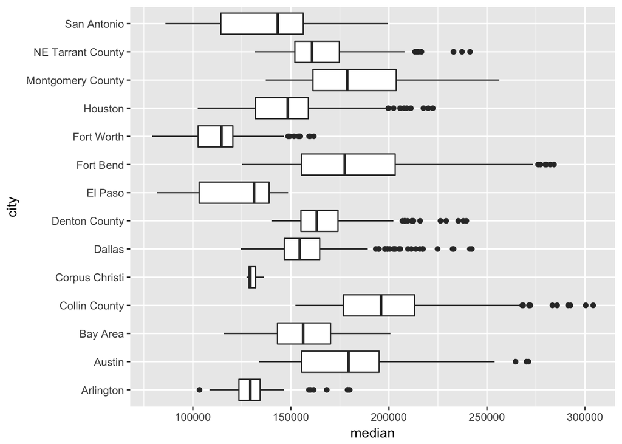

```r
tx_subset %>% ggplot(mapping=aes(x=city, y=median)) + geom_boxplot() + coord_flip()
```

#### Why might we want to filter out all cities and months with sales less than 500?

Observations with sales less than 500 may have unusual values and might not provide meaningful distributions.